# Binomial and multinomial regression models

Aylin Mumcular

21 November 2017

# Challenger disaster

[figure not shown]

What happened

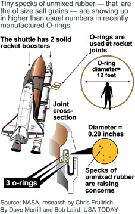

Questioning the role of oring failure in Challenger disaster

Let’s investigate if the failure of the orings is related to temperature at the time of the mission departure.

#Explore

| temp | damage |
| --- | --- |
| 9.333333 | 5 |
| 11.111111 | 1 |
| 11.555556 | 1 |
| 13.777778 | 1 |
| 15.111111 | 0 |
| 15.555556 | 0 |
| 15.555556 | 0 |
| 15.555556 | 0 |
| 16.000000 | 0 |
| 16.444444 | 0 |

[output cut: 13 more lines]

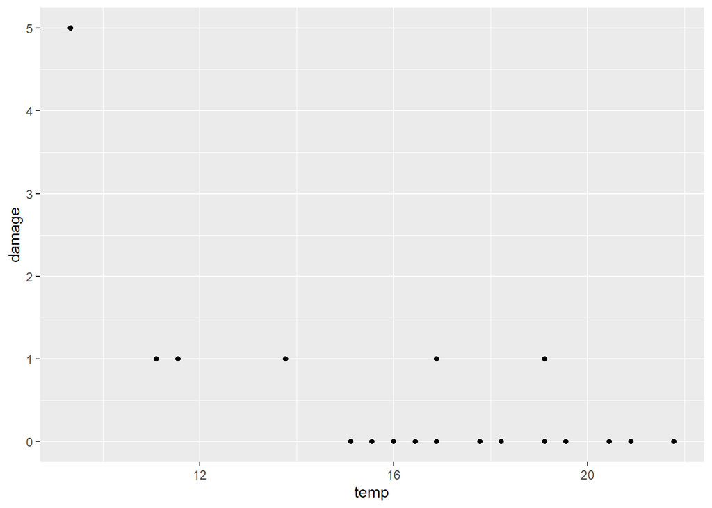

Let’s fit a binomial regression to the data. To predict the probability of damage, use the following:

```
##
## Call:  glm(formula = cbind(damage, 6 - damage) ~ temp, family = "binomial",
##     data = d)
##
## Coefficients:
## (Intercept)         temp
##      4.7435      -0.4865
##
## Degrees of Freedom: 22 Total (i.e. Null);  21 Residual
## Null Deviance:       38.9
## Residual Deviance: 16.91     AIC: 33.67
```

```
##
## Call:
## glm(formula = cbind(damage, 6 - damage) ~ temp, family = "binomial",
##     data = d)
##
## Deviance Residuals:
##     Min       1Q   Median       3Q      Max
## -0.9529  -0.7345  -0.4393  -0.2079   1.9565
##
## Coefficients:
##             Estimate Std. Error z value Pr(>|z|)
## (Intercept)   4.7435     1.6154   2.936  0.00332 **
## temp         -0.4865     0.1196  -4.066 4.78e-05 ***
## ---
## Signif. codes:  0 '***' 0.001 '**' 0.01 '*' 0.05 '.' 0.1 ' ' 1
##
## (Dispersion parameter for binomial family taken to be 1)
##
##     Null deviance: 38.898  on 22  degrees of freedom
## Residual deviance: 16.912  on 21  degrees of freedom
## AIC: 33.675
##
## Number of Fisher Scoring iterations: 6
```

I checked that deviance equals 16.912 with 21 d.o.f. The pvalue turns out to be 0.7164267.

```
## [1] 0.7164267
```

Because pvalue is greater than 5%, I am unable to reject the current model. (H0:Current model is correct)

Test $H_0: \beta\mathrm{temp}=0$. Using Wald test

```
##
## Call:
## glm(formula = cbind(damage, 6 - damage) ~ temp, family = "binomial",
##     data = d)
##
## Deviance Residuals:
##     Min       1Q   Median       3Q      Max
## -0.9529  -0.7345  -0.4393  -0.2079   1.9565
##
## Coefficients:
##             Estimate Std. Error z value Pr(>|z|)
## (Intercept)   4.7435     1.6154   2.936  0.00332 **
## temp         -0.4865     0.1196  -4.066 4.78e-05 ***
## ---
## Signif. codes:  0 '***' 0.001 '**' 0.01 '*' 0.05 '.' 0.1 ' ' 1
##
## (Dispersion parameter for binomial family taken to be 1)
##
##     Null deviance: 38.898  on 22  degrees of freedom
## Residual deviance: 16.912  on 21  degrees of freedom
## AIC: 33.675
##
## Number of Fisher Scoring iterations: 6
```

Because pvalue (4.78e-05) of z-test (Wald test) is practically zero, I reject the null hypothesis, which implies that temperature and number of damages are associated. (Coefficient is negative, negatively associated)

```
##         1
## 0.9930342
```

Let’s plot the failure probability as a function of temperature.

To model probability of damage with binomial regression, I should feed to glm cbind(damage(success), failures) in other words cbind(damage, 6-damage).

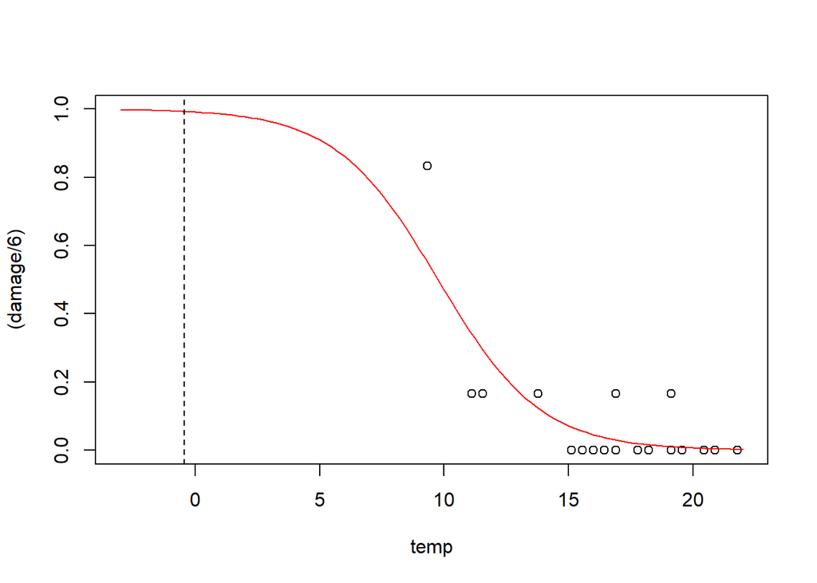

Let’s calculate the confidence interval on the damage probability

```
## [1] 0.8355008 0.9930342 0.9997501
```